# SEFL Porites astreoides 2bRAD

Erin Shilling

8/23/2021

# About this document

```r
if (!require("pacman")) install.packages("pacman")

pacman::p_load_gh("pmartinezarbizu/pairwiseAdonis/pairwiseAdonis", "ropensci/rnaturalearthhires")
pacman::p_load("cowplot", "ggrepel", "ggspatial", "maps", "paletteer", "patchwork", "rgdal", "rnaturalearth", "sf", "tidyverse", "reshape2", "MCMC.OTU", "pairwiseAdonis", "RColorBrewer", "Redmonder", "flextable", "lubridate", "officer", "adegenet", "dendextend", "gdata", "ggdendro", "hierfstat", "Imap", "kableExtra", "poppr", "StAMPP", "vcfR", "vegan", "boa", "measurements", "magick", "rgeos", "magrittr", "ggplot2", "rstatix")
```

Map and shapefile data Here we are setting up shape files and base maps as well as sample meta data.

```r
#packages: tidyverse, lubridate, measurements, sf, rnaturalearth

pastSamples = read.csv("data_files/poritesastreoidesMetaData_clonesremoved.csv", header = TRUE) %>% select(sample = tube_id, !sample_id)

pastSamples$region = factor(pastSamples$region)
pastSamples$region = factor(pastSamples$region, levels = levels(pastSamples$region)[c(4, 2, 5, 1, 3)])
pastSamples$collection_date = mdy(pastSamples$collection_date) %>% format("%d %b %Y")
pastSamples$depthM = conv_unit(pastSamples$collection_depth_ft, from = "ft", to = "m") %>% round(1)

seflSites = pastSamples %>% group_by(region)%>% summarize(latDD = first(site_lat), longDD = first(site_long), depthRangeM = paste(min(depthM), "-", max(depthM), sep = ""), n = n(), date = as.character(min(collection_date))) %>% droplevels() %>% as.data.frame()

states = st_as_sf(ne_states(country = c("United States of America")))
countries = st_as_sf(ne_countries(country = c("Cuba", "The Bahamas")))
florida = read_sf("data_files/shp/flCountiesLo.shp") %>% st_transform(crs = 4326)
frt = read_sf("data_files/shp/flReefs.shp") %>% st_transform(crs = 4326)

countyNames = st_as_sf(maps::map("county", plot = FALSE, fill = TRUE)) %>% st_transform(crs = 4326) %>% filter(grepl("florida", ID)) %>% filter(grepl("palm beach|broward|martin", ID))
countyNames$ID = c("Broward \nCounty", "Martin \nCounty", "Palm Beach \nCounty")

popLabs = pastSamples %>% group_by(region)%>% summarize(latDD = first(site_lat), longDD = first(site_long))
levels(popLabs$region) = c("St. Lucie", "Jupiter", "West Palm", "Boynton", "Ft. Lauderdale")
```

Florida polygon Next we build a hi-res polygon of FL with the study site marked and a zoomed in map of the colony locations. We use `ggspatial` to add a north arrow and scale bar to the main map.

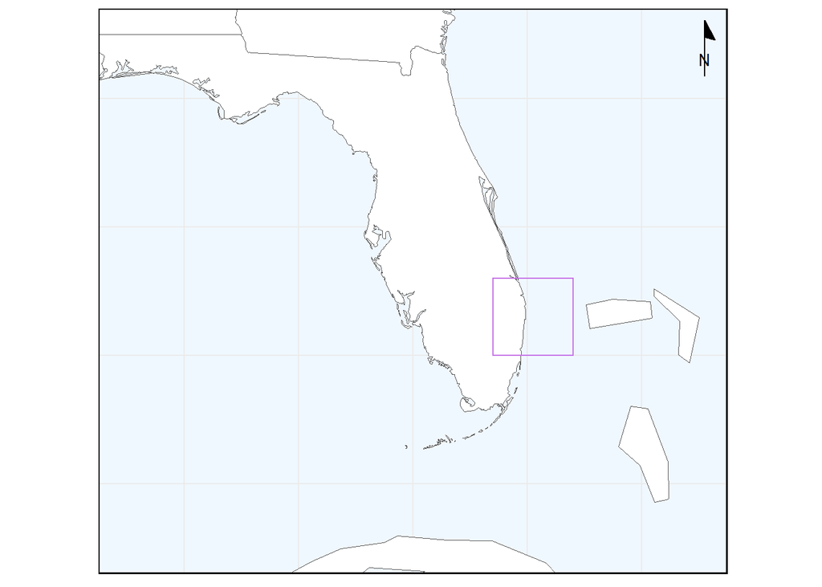

```r
#packages: paletteer, ggspatial
floridaMap = ggplot() +
  geom_sf(data = states, fill = "white", size = 0.25) +
  geom_sf(data = countries, fill = "white", size = 0.25) +
  geom_rect(aes(xmin = -80.6, xmax = -79.2, ymin = 26, ymax = 27.2), color = paletteer_d("vapoRwave::vapoRwave")[8], fill = NA) +
  coord_sf(xlim = c(-87, -77), ylim = c(23, 31)) +
  annotation_north_arrow(location = "tr", which_north = "true", style = north_arrow_minimal(), height = unit(1.2, "cm"), pad_x = unit(-0.25, "cm")) +
  theme_bw() +
  theme(panel.background = element_rect(fill = "aliceblue"),
        panel.border = element_rect(color = "black", size = 0.75, fill = NA),
        plot.background = element_blank(),
        axis.title = element_blank(),
        axis.ticks = element_blank(),
        axis.text = element_blank(),
        legend.position = "none")

floridaMap
```

Final map of sites Create a map of study sites with insets and legend

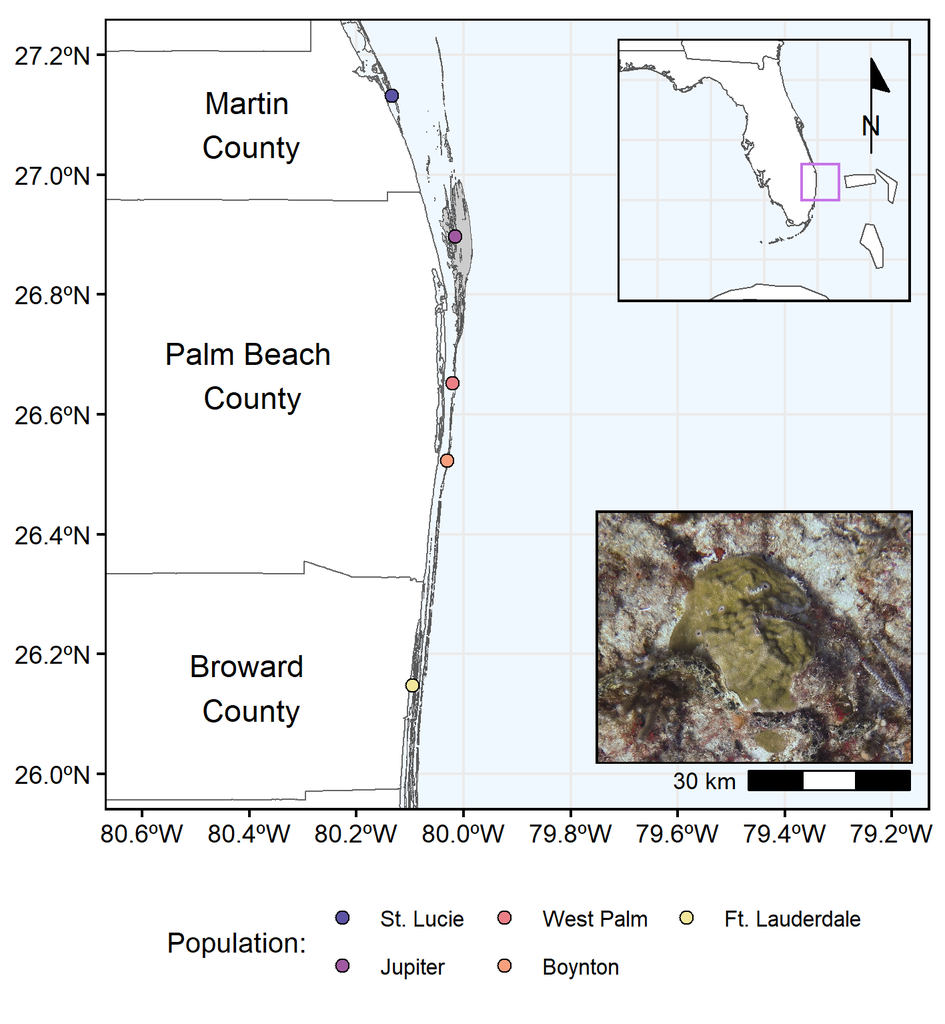

```r
#packages: magick, cowplot
flPal = paletteer_d("rcartocolor::Sunset")[c(7, 6, 4, 3, 1)]

latLab = paste(format(abs(seq(26, 27.2, by = 0.2)), nsmall = 1), "ºN", sep = "")
longLab = paste(format(abs(seq(-80.6, -79.2, by = 0.2)), nsmall = 1), "ºW", sep = "")

siteMap = ggplot() +
  geom_sf(data = florida, fill = "white", color = "gray40", size = 0.25) +
  geom_sf(data = countries, fill = "white", color = "gray40", size = 0.25) +
  geom_sf(data = frt, fill = "gray80", size = 0) +
  geom_point(data = popLabs, aes(x = longDD, y = latDD, fill = region), shape = 21, size = 2) +
  geom_sf_text(data = countyNames, aes(label = ID), nudge_x = c(0.1, 0, 0.1),
               nudge_y = c(0, -.025, -0.1)) +
  scale_fill_manual(values = flPal, name = "Population:") +
  coord_sf(xlim = c(-80.6, -79.2), ylim = c(26, 27.2)) +
  scale_x_continuous(breaks = c(seq(-80.6, -79.2, by = 0.2)), labels = longLab) +
  scale_y_continuous(breaks = c(seq(26, 27.2, by = 0.2)), labels = latLab) +
  annotation_scale(location = "br") +
  guides(fill = guide_legend(ncol = 3)) +
  theme_bw() +
  theme(panel.background = element_rect(fill = "aliceblue"),
        panel.border = element_rect(color = "black", size = 0.75, fill = NA),
        plot.background = element_blank(),
        axis.ticks = element_line(color = "black"),
        axis.text = element_text(color = "black"),
        axis.title = element_blank(),
        legend.background = element_blank(),
        legend.title = element_text(size = 10),
        legend.text = element_text(size = 8),
        legend.key = element_blank(),
        legend.position = "bottom",
        legend.direction = "horizontal")

#add a picture of P. astreoides
pastPic = image_read("C:/Users/erin_/Documents/GitHub/SEFL_Pastreoides_2bRAD/data_files/past.png") %>%
  image_border("black", "10x10")

seflMap = ggdraw() +
  draw_plot(siteMap) +
  draw_plot(floridaMap, x = 0.63, y = 0.655, width = 0.35, height = 0.35) +
  draw_image(pastPic, x = 0.63, y = 0.21, width = 0.336, height = 0.336)

# seflMap
ggsave("C:/Users/erin_/Documents/GitHub/SEFL_Pastreoides_2bRAD/figures/pastMap.png", plot = seflMap, width = 12, height = 13, units = "cm", dpi = 300)
ggsave("C:/Users/erin_/Documents/GitHub/SEFL_Pastreoides_2bRAD/figures/pastMap.tiff", plot = seflMap, width = 12, height = 13, units = "cm", dpi = 300)
ggsave("C:/Users/erin_/Documents/GitHub/SEFL_Pastreoides_2bRAD/figures/pastMap.eps", plot = seflMap, width = 12, height = 13, units = "cm", dpi = 300)
```

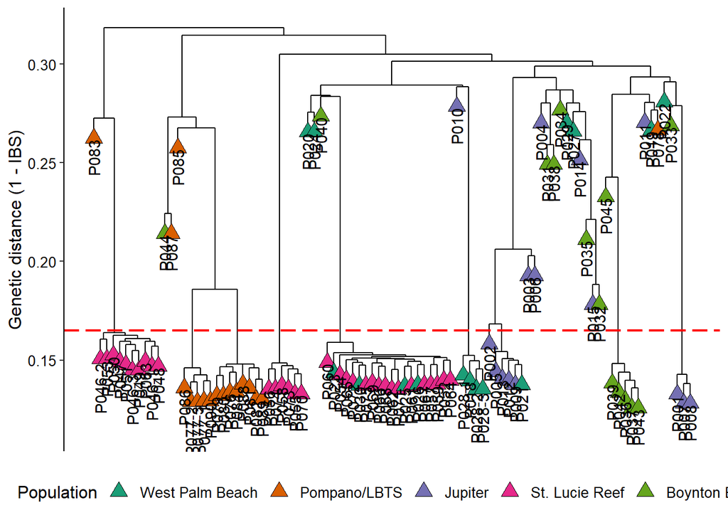

```r
#packages: tidyverse, ggdendro
cloneBams = read.csv("C:/Users/erin_/Documents/GitHub/SEFL_Pastreoides_2bRAD/data_files/poritesastreoidesMetaData.csv")
cloneMa = as.matrix(read.table("C:/Users/erin_/Documents/GitHub/SEFL_Pastreoides_2bRAD/data_files/pastClones.ibsMat"))
dimnames(cloneMa) = list(cloneBams[,1],cloneBams[,1])
clonesHc = hclust(as.dist(cloneMa),"ave")
clonePops = cloneBams$region
cloneDend = cloneMa %>% as.dist() %>% hclust(.,"ave") %>%
  as.dendrogram()
cloneDData = cloneDend %>% dendro_data()

# Making the branches hang shorter so we can easily see clonal groups
cloneDData$segments$yend2 = cloneDData$segments$yend
for(i in 1:nrow(cloneDData$segments)) {
  if (cloneDData$segments$yend2[i] == 0) {
    cloneDData$segments$yend2[i] = (cloneDData$segments$y[i] - 0.01)}}

cloneDendPoints = cloneDData$labels
cloneDendPoints$pop = clonePops[order.dendrogram(cloneDend)]
rownames(cloneDendPoints) = cloneDendPoints$label

# Making points at the leaves to place symbols for populations
point = as.vector(NA)
for(i in 1:nrow(cloneDData$segments)) {
  if (cloneDData$segments$yend[i] == 0) {
    point[i] = cloneDData$segments$y[i] - 0.01
  } else {
    point[i] = NA}}

cloneDendPoints$y = point[!is.na(point)]

techReps = c("P028-1", "P028-2", "P028-3", "P046-1", "P046-2", "P046-3", "P077-1", "P077-2", "P077-3")

cloneDendPoints$pop = factor(cloneDendPoints$pop)
cloneDendPoints$pop = factor(cloneDendPoints$pop,levels(cloneDendPoints$pop)[c(5,3,6,2,4,1)])

cloneDendA = ggplot() +
  geom_segment(data = segment(cloneDData), aes(x = x, y = y, xend = xend, yend = yend2), size = 0.5) +
  geom_point(data = cloneDendPoints, aes(x = x, y = y, fill = pop), size = 4, stroke = 0.25, shape = 24) +
  scale_fill_brewer(palette = "Dark2", name = "Population") +
  geom_hline(yintercept = 0.165, color = "red", lty = 5, size = 0.75) + # creating a dashed line to indicate a clonal distance threshold
  geom_text(data = subset(cloneDendPoints, subset = label %in% techReps), aes(x = x, y = (y - .015), label = label), angle = 90) + # spacing technical replicates further from leaf
  geom_text(data = subset(cloneDendPoints, subset = !label %in% techReps), aes(x = x, y = (y - .010), label = label), angle = 90) +
  labs(y = "Genetic distance (1 - IBS)") +
  theme_classic()

cloneDend = cloneDendA + theme(
  axis.title.x = element_blank(),
  axis.text.x = element_blank(),
  axis.line.x = element_blank(),
  axis.ticks.x = element_blank(),
  axis.title.y = element_text(size = 12, color = "black", angle = 90),
  axis.text.y = element_text(size = 10, color = "black"),
  axis.line.y = element_line(),
  axis.ticks.y = element_line(),
  panel.grid = element_blank(),
  panel.border = element_blank(),
  panel.background = element_blank(),
  plot.background = element_blank(),
  legend.key = element_blank(),
  legend.title = element_text(size = 12),
  legend.text = element_text(size = 10),
  legend.position = "bottom")

cloneDend
```

```r
ggsave("C:/Users/erin_/Documents/GitHub/SEFL_Pastreoides_2bRAD/figures/cloneDend.png", plot = cloneDend, height = 8, width = 35, units = "in", dpi = 300)
ggsave("C:/Users/erin_/Documents/GitHub/SEFL_Pastreoides_2bRAD/figures/cloneDend.eps", plot = cloneDend, height = 8, width = 35, units = "in", dpi = 300)
```

```r
#packages: tidyverse, vcfR, adegenet, poppr
#reading in bcf file
pastVcf = read.vcfR("C:/Users/erin_/Documents/GitHub/SEFL_Pastreoides_2bRAD/data_files/pastNoClones.bcf", verbose = TRUE)
```

[output not shown]

```r
#convert to genlight files for poppr
pastGenlightPopulation = vcfR2genlight(pastVcf, n.cores = 1)

#taking metadata file, without technical replicates & clones, reads in population data for each sample
popData = read.csv("C:/Users/erin_/Documents/GitHub/SEFL_Pastreoides_2bRAD/data_files/poritesastreoidesMetaData_clonesremoved.csv") %>% select("sample" = tube_id, "pop" = region)

#setting up amova
strata(pastGenlightPopulation) = data.frame(popData)
setPop(pastGenlightPopulation) = ~pop
#Runs AMOVA looking at samples by region
amova <- poppr.amova(pastGenlightPopulation, ~pop)
amova
```

```
## $call
## ade4::amova(samples = xtab, distances = xdist, structures = xstruct)
##
## $results
##                            Df    Sum Sq  Mean Sq
## Between pop                 4  16529.28 4132.320
## Between samples Within pop 31  91026.08 2936.325
## Within samples             36 114965.00 3193.472
## Total                      71 222520.36 3134.090
##
## $componentsofcovariance
##                                             Sigma          %
## Variations  Between pop                  85.93975   2.727520
## Variations  Between samples Within pop -128.57352  -4.080613
## Variations  Within samples             3193.47222 101.353093
## Total variations                       3150.83846 100.000000
##
## $statphi
##                           Phi
## Phi-samples-total -0.01353093
## Phi-samples-pop   -0.04195033
## Phi-pop-total      0.02727520
```

```r
set.seed(694)
amovasignif <- randtest(amova, nrepet = 99)
amovasignif$names
```

```
## [1] "Variations within samples"  "Variations between samples"
## [3] "Variations between pop"
```

```r
amovasignif$obs
```

```
## [1] 3193.47222 -128.57352   85.93975
```

```r
amovasignif$pvalue
```

```
## [1] 0.66 0.88 0.01
```

```r
amovaPerc = paste(round(amova$componentsofcovariance$`%`[1], 2), "%",sep="")
amovaP = amovasignif$pvalue[3]

amovaPerc
```

```
## [1] "2.73%"
```

```r
amovaP
```

```
## [1] 0.01
```

Only significant differences between populations, explains 2.73% of variation

```r
# packages: tidyverse, paletteer, vegan if use vectors
#calculating depth & latitude vectors
pastMa = as.matrix(read.table("C:/Users/erin_/Documents/GitHub/SEFL_Pastreoides_2bRAD/data_files/pastNoClones.ibsMat"))
pastMds = cmdscale(pastMa, eig = TRUE, x.ret = TRUE)
meta = read.csv("C:/Users/erin_/Documents/GitHub/SEFL_Pastreoides_2bRAD/data_files/poritesastreoidesMetaData_clonesremoved.csv")

env=dplyr::select(meta, collection_depth_m, site_lat)
#env=cbind(env,envData)

envDrivers=envfit(pastMds, env, permutations = 999)
envDriversScores <- as.data.frame(scores(envDrivers, display = "vectors"))
#extracts relevant scores from envifit
A <- as.list(envDrivers$vectors)
pvals<-as.data.frame(A$pvals)
arrows<-as.data.frame(A$arrows*sqrt(A$r))
C<-cbind(arrows, pvals)

#                         Dim1        Dim2 A$pvals
#collection_depth_m -0.5893338 -0.02474275   0.004
#site_lat           -0.5456895  0.20714215   0.004

#$r
#collection_depth_m           site_lat
#         0.3479266          0.3406849

#Cred<-subset(C,pvals<0.01) #Filters species with highly significant loadings

Cred <- cbind(C, Drivers = rownames(C))
Cred$Drivers <- as.character(Cred$Drivers)
Cred["popDepth", "Drivers"] <- "Depth"
Cred["lat", "Drivers"] <- "Latitude"

#remove from here if keep vectors
pastMa = as.matrix(read.table("C:/Users/erin_/Documents/GitHub/SEFL_Pastreoides_2bRAD/data_files/pastNoClones.ibsMat"))
pastMds = cmdscale(pastMa, eig = TRUE, x.ret = TRUE)

# Determine percent variation captured on each axis
# Calculate the eigenvalues so later we can figure out % variation shown on each Principal Coordinate
pastPcoaVar = round(pastMds$eig/sum(pastMds$eig)*100, 1)
head(pastPcoaVar)
```

```
## [1] 8.7 7.0 6.3 4.3 3.9 3.7
```

```r
# Format data to plot
pastPcoaValues = pastMds$points
head(pastPcoaValues)
```

```
##             [,1]         [,2]
## [1,] -0.13117451 -0.105262017
## [2,] -0.12360879 -0.088852192
## [3,]  0.01292516  0.007190786
## [4,] -0.12945599 -0.082992978
## [5,]  0.01168498  0.013646703
## [6,] -0.13753297 -0.099806631
```

```r
# 2-column tab-delimited table of individual assignments to populations; must be in the same order as samples in the bam list or vcf file.
pastI2P = read.csv("C:/Users/erin_/Documents/GitHub/SEFL_Pastreoides_2bRAD/data_files/poritesastreoidesMetaData_clonesremoved.csv") %>% select("sample" = tube_id, "pop" = region)

row.names(pastI2P) = pastI2P[,1]
pastPcoaValues=cbind(pastI2P, pastPcoaValues)
pastPcoaValues =as.data.frame(pastPcoaValues, sample = rownames(pastPcoaValues))
colnames(pastPcoaValues)[c(3,4)] = c("PCo1", "PCo2")
head(pastPcoaValues)
```

```
##      sample     pop        PCo1         PCo2
## P002   P002 Jupiter -0.13117451 -0.105262017
## P003   P003 Jupiter -0.12360879 -0.088852192
## P004   P004 Jupiter  0.01292516  0.007190786
## P006   P006 Jupiter -0.12945599 -0.082992978
## P008   P008 Jupiter  0.01168498  0.013646703
## P009   P009 Jupiter -0.13753297 -0.099806631
```

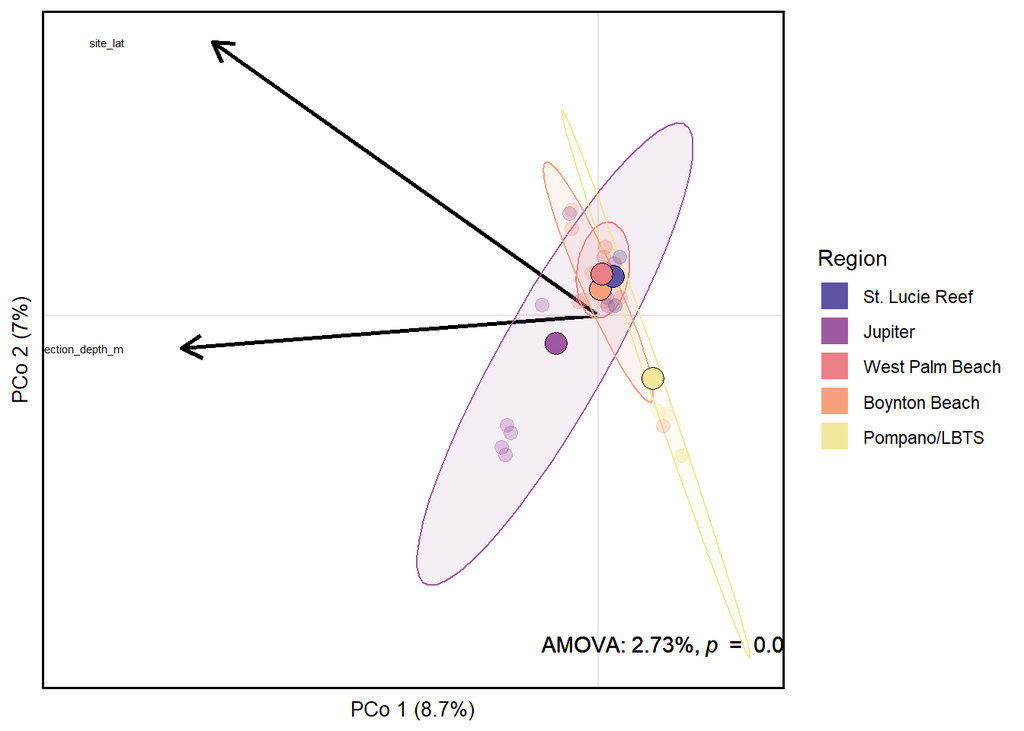

```r
pastPCoA = merge(pastPcoaValues, aggregate(cbind(mean.x=PCo1,mean.y=PCo2)~pop, pastPcoaValues, mean), by="pop")

pastPCoA$pop = factor(pastPCoA$pop)
pastPCoA$pop = factor(pastPCoA$pop, levels(pastPCoA$pop)[c(4, 2, 5, 1, 3)])

flPal = paletteer_d("rcartocolor::Sunset")[c(7, 6, 4, 3, 1)]

pastPcoaPlotA = ggplot(pastPCoA, aes(x = PCo1, y = PCo2, color = pop, fill = pop)) +
    geom_segment(data = Cred, aes(x = 0, xend = Dim1, y = 0, yend = Dim2), arrow = arrow(length = unit(0.4, "cm")), color = "black", size=1, inherit.aes = FALSE) + # adds vectors
  geom_text(data = Cred, aes(x = ((Dim1)-0.15), y = Dim2, label = Drivers), size = 2, inherit.aes = FALSE)+ # adds labels to vectors
  geom_hline(yintercept = 0, color = "gray90", size = 0.5) +
  geom_vline(xintercept = 0, color = "gray90", size = 0.5) +
  #ellipses
  stat_ellipse(data = pastPCoA, type = "t", geom = "polygon", alpha = 0.1) +
  #individuals indicated by small transparent circles
  geom_point(aes(x = PCo1, y = PCo2), size = 3, alpha = 0.3, show.legend = FALSE) +
  #population centroids indicated by large circles
  geom_point(aes(x = mean.x, y = mean.y), size = 5, color = "black", shape = 21) +
   annotate(geom = "text", x = 0.1, y = -0.25, label = bquote("AMOVA:"~.(amovaPerc)*","~italic(p)~" = "~.(amovaP))) +
  scale_fill_manual(values = flPal, name = "Region") +
  scale_color_manual(values = flPal, guide = NULL) +
  xlab(paste ("PCo 1 (", pastPcoaVar[1],"%)", sep = "")) + #Prints percent variation explained by first axis
  ylab(paste ("PCo 2 (", pastPcoaVar[2],"%)", sep = "")) + #Prints percent variation explained by second axis
  guides(shape = guide_legend(order = 2), linetype = guide_legend(override.aes = list(linetype = c(1,2), alpha = 1, color = "black", fill = NA), order = 3), fill = guide_legend(override.aes = list(shape = 22, size = 5, color = NA, alpha = NA), order = 1))+
  theme_bw()

pastPcoaPlot = pastPcoaPlotA +
  theme(axis.title.x = element_text(color = "black", size = 10),
        axis.text.x = element_blank(),
        axis.ticks.x = element_blank(),
        axis.line.x = element_blank(),
        axis.title.y = element_text(color = "black", size = 10),
        axis.text.y = element_blank(),
        axis.ticks.y = element_blank(),
        axis.line.y = element_blank(),
        legend.position = "right",
        panel.border = element_rect(color = "black", size = 1),
        panel.background = element_rect(fill = "white"),
        panel.grid.major = element_blank(),
        panel.grid.minor = element_blank())

pastPcoaPlot
```

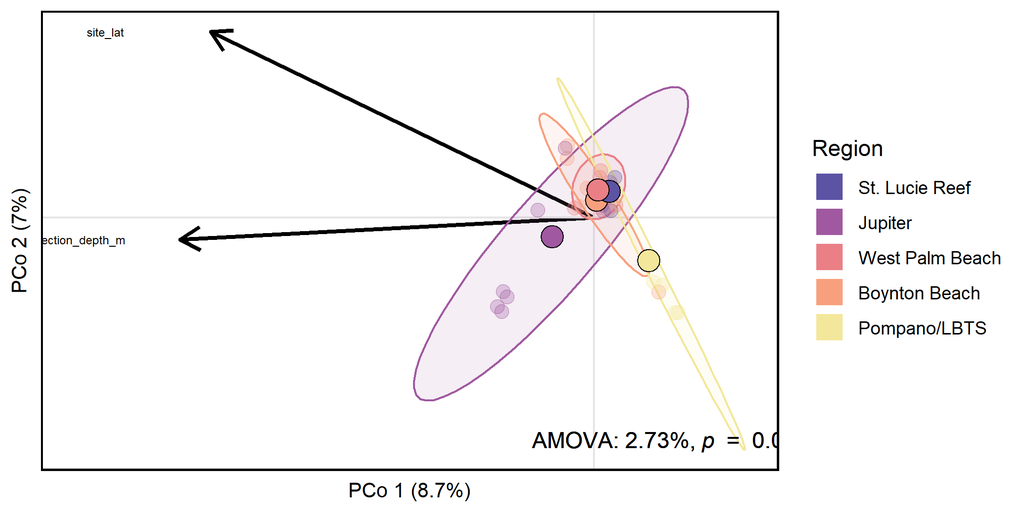

```r
ggsave("C:/Users/erin_/Documents/GitHub/SEFL_Pastreoides_2bRAD/figures/pcoaPlot.png", plot = pastPcoaPlot, height = 3.5, width = 7, units = "in", dpi = 300)
ggsave("C:/Users/erin_/Documents/GitHub/SEFL_Pastreoides_2bRAD/figures/pcoaPlot.pdf", plot = pastPcoaPlot, height = 3.5, width = 7, units = "in", dpi = 300)
ggsave("C:/Users/erin_/Documents/GitHub/SEFL_Pastreoides_2bRAD/figures/pcoaPlot.tiff", plot = pastPcoaPlot, height = 3.5, width = 7, units = "in", dpi = 300)
```

Calculating pairwise Fst values between populations & generating heat map of the values

```r
#packages: tidyverse, vcfR, adegenet, StAMPP, gdata, reshape2, paletteer
pastVcf = read.vcfR("C:/Users/erin_/Documents/GitHub/SEFL_Pastreoides_2bRAD/data_files/pastNoClones.bcf", verbose = FALSE)
pastGenlightPopulation = vcfR2genlight(pastVcf, n.cores = 1)
locNames(pastGenlightPopulation) = paste(pastVcf@fix[,1],pastVcf@fix[,2],sep="_")

popData = read.csv("C:/Users/erin_/Documents/GitHub/SEFL_Pastreoides_2bRAD/data_files/poritesastreoidesMetaData_clonesremoved.csv") %>% select("sample" = tube_id, "pop" = region)

strata(pastGenlightPopulation) = data.frame(popData)
setPop(pastGenlightPopulation) = ~pop

pastGenlightPopulation$pop = factor(pastGenlightPopulation$pop)
pastGenlightPopulation$pop = factor(pastGenlightPopulation$pop,
                                levels(pastGenlightPopulation$pop)[c(4, 1, 2, 3, 5)])

set.seed(694)

#99 permutations
sefl.fst <- stamppFst(pastGenlightPopulation, nboots = 99, percent = 95, nclusters = 2)
sefl.fst$Fsts
```

```
##                    Jupiter West Palm Beach Boynton Beach St. Lucie Reef
## Jupiter                 NA              NA            NA             NA
## West Palm Beach 0.02039765              NA            NA             NA
## Boynton Beach   0.01265314     0.002712526            NA             NA
## St. Lucie Reef  0.03927415    -0.003273737    0.01232193             NA
## Pompano/LBTS    0.06841166     0.047436077    0.04013369     0.03030518
##                 Pompano/LBTS
## Jupiter                   NA
## West Palm Beach           NA
## Boynton Beach             NA
## St. Lucie Reef            NA
## Pompano/LBTS              NA
```

```r
sefl.fst$Pvalues
```

```
##                 Jupiter West Palm Beach Boynton Beach St. Lucie Reef
## Jupiter              NA              NA            NA             NA
## West Palm Beach       0              NA            NA             NA
## Boynton Beach         0        0.000000            NA             NA
## St. Lucie Reef        0        0.989899             0             NA
## Pompano/LBTS          0        0.000000             0              0
##                 Pompano/LBTS
## Jupiter                   NA
## West Palm Beach           NA
## Boynton Beach             NA
## St. Lucie Reef            NA
## Pompano/LBTS              NA
```

[figure not shown]

```r
#Generating heat map of pairwise Fst values
#reordering my samples to stay formatted properly for the matrix, and still have them go north to south
pop.order = c("Pompano/LBTS", "Boynton Beach", "West Palm Beach", "Jupiter", "St. Lucie Reef")

#reads in Fst matrix
snpFstMa <- as.matrix(sefl.fst$Fsts)
#rebuilding the matrix based on order of populations
upperTriangle(snpFstMa, byrow = TRUE) <- lowerTriangle(snpFstMa)
snpFstMa <- snpFstMa[,pop.order] %>% .[pop.order,]
snpFstMa[upper.tri(snpFstMa)] <- NA
snpFstMa <- as.data.frame(snpFstMa)

snpFstMa$Pop = factor(row.names(snpFstMa))

snpQMa <- as.matrix(sefl.fst$Pvalues)
upperTriangle(snpQMa, byrow=TRUE) <- lowerTriangle(snpQMa)
snpQMa <- snpQMa[,pop.order] %>%
  .[pop.order,]
snpQMa[upper.tri(snpQMa)] <- NA
snpQMa <- as.data.frame(snpQMa)
snpQMa$Pop = factor(row.names(snpQMa), levels = unique(pop.order))

snpFstMa$Pop = factor(row.names(snpFstMa), levels = unique(pop.order))
snpFst = melt(snpFstMa, id.vars = "Pop", value.name = "Fst", variable.name = "Pop2", na.rm = FALSE)
snpFst$Fst = round(snpFst$Fst, 3)
snpFst = snpFst %>% mutate(Fst = replace(Fst, Fst < 0, 0))

snpQ = melt(snpQMa, id.vars = "Pop", value.name = "Pval", variable.name = "Pop2", na.rm = FALSE)
snpQ$Qval = p.adjust(snpQ$Pval, method = "BH")

snpFst$region = snpFst$Pop
snpFst$region = factor(gsub("\\n.*", "", snpFst$region))
snpFst$region = factor(snpFst$region, levels = levels(snpFst$region)[c(4, 2, 5, 1, 3)])

snpFst$region2 = snpFst$Pop2
snpFst$region2 = factor(gsub("\\n.*", "", snpFst$region2))
snpFst$region2 = factor(snpFst$region2, levels = levels(snpFst$region2)[c(4, 2, 5, 1, 3)])

snpFst$Fst = sprintf('%.3f', snpFst$Fst)
snpFst$Fst = factor(gsub("\\NA", NA, snpFst$Fst))
snpFst$Fst = factor(gsub("\\.000", "", snpFst$Fst))
snpFst$Fst = factor(gsub("\\-", "", snpFst$Fst))

snpHeatmapA = ggplot(data = snpFst, aes(Pop, Pop2, fill = as.numeric(as.character(Fst))))+
  geom_tile(color = "white") +

  geom_segment(data = snpFst, aes(x = 0.48, xend = -0.62, y = Pop, yend = Pop, color = region), size = 19) +
  geom_segment(data = snpFst, aes(x = Pop2, xend = Pop2, y = 0.45, yend = -0.6, color = region2), size = 62.5) +
  scale_color_manual(values = flPal[], guide = NULL) +
  scale_fill_gradient(low = "white", high = "red", limit = c(0, 0.07), space = "Lab", name = expression(paste(italic("F")[ST])), na.value = "white",  guide = "colourbar")+
  geom_text(data = snpFst, aes(Pop, Pop2, label = Fst), color = ifelse(snpQ$Qval <= 0.05,"black", "darkgrey"), size = ifelse(snpQ$Qval < 0.05, 6, 5), fontface = ifelse (snpQ$Qval < 0.05, "bold", "plain")) +
  guides(fill = guide_colorbar(barwidth = 12, barheight = 1, title.position = "top", title.hjust = 0.5)) +
  scale_y_discrete(position = "left") +
  scale_x_discrete(limits = rev(levels(snpFst$Pop))[c(1:5)]) +
  coord_cartesian(xlim = c(1, 5), ylim = c(1, 5), clip = "off") +
  theme_minimal()

snpHeatmap = snpHeatmapA + theme(
  axis.text.x = element_text(vjust = 1, size = 16, hjust = 0.5, color = "black"),
  axis.text.y = element_text(size = 16, color = "black"),
  axis.title.x = element_blank(),
  axis.title.y = element_blank(),
  panel.grid.major = element_blank(),
  panel.border = element_blank(),
  axis.ticks = element_blank(),
  legend.position = c(0.5, 0.87),
  legend.direction = "horizontal",
  legend.title = element_text(size = 16),
  legend.text = element_text(size = 14),
  plot.title = element_text(size = 16)
)

snpHeatmap
```

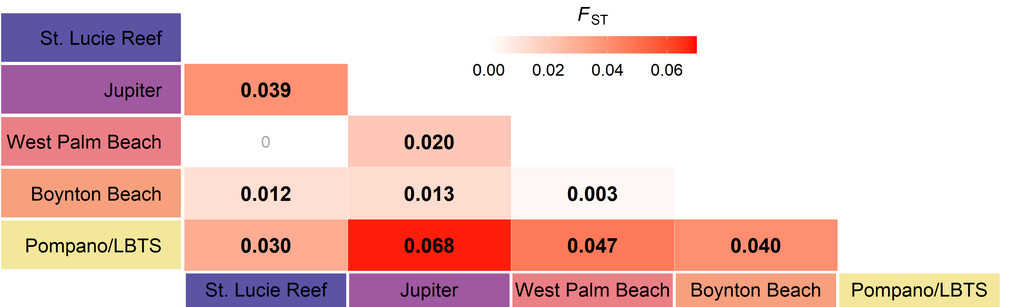

```r
ggsave("C:/Users/erin_/Documents/GitHub/SEFL_Pastreoides_2bRAD/figures/fstHeatMap.png", plot = snpHeatmap, width = 30, height = 9, units = "cm", dpi = 300)
ggsave("C:/Users/erin_/Documents/GitHub/SEFL_Pastreoides_2bRAD/figures/fstHeatMap.eps", plot = snpHeatmap, width = 30, height = 9, units = "cm", dpi = 300)
```

Heterozygosity & Inbreeding Calculating values for later plot analysis

```r
# packages: tidyverse, rstatix
#rstatix package for Tukey post hoc
#Read in population data
popData = read.csv("C:/Users/erin_/Documents/GitHub/SEFL_Pastreoides_2bRAD/data_files/poritesastreoidesMetaData_clonesremoved.csv") %>% select("sample" = tube_id, "Region" = region)

popData$a = c(0:35)
popData$Region = factor(popData$Region)
popData$Region = factor(popData$Region, levels = levels(popData$Region)[c(4, 2, 5, 1, 3)])
hetAll = read.table("C:/Users/erin_/Documents/GitHub/SEFL_Pastreoides_2bRAD/data_files/hetAllSites")

colnames(hetAll) = c("sample", "All")
hetAll$sample = popData$sample

HetSNPs = read.table("C:/Users/erin_/Documents/GitHub/SEFL_Pastreoides_2bRAD/data_files/HetSNPs")
colnames(HetSNPs) = c("sample", "SNPs")
HetSNPs$sample = popData$sample

pastBreed = read.delim("C:/Users/erin_/Documents/GitHub/SEFL_Pastreoides_2bRAD/data_files/newres")
pastBreed2 = pastBreed %>% group_by(a) %>% select("inbreed" = Fa)
pastBreed3 = pastBreed %>% group_by(b) %>% select("inbreed" = Fb)
pastBreed = bind_rows(pastBreed2, pastBreed3) %>% group_by(a) %>% summarize("inbreed" = mean(inbreed))

pastRelate = read.delim("C:/Users/erin_/Documents/GitHub/SEFL_Pastreoides_2bRAD/data_files/newres")
pastRelate2 = pastRelate %>% group_by(a, b) %>% select("relate" = rab)
pastRelate2 = pastRelate2 %>% left_join(popData, by = "a") %>% left_join(popData, by = c("b" = "a"), suffix = c(".a", ".b"))
pastRelate = pastRelate2 %>% filter(Region.a == Region.b) %>% rename(Region = Region.a)
het = left_join(popData, hetAll, by = "sample") %>% left_join(HetSNPs, by = "sample") %>% mutate("inbreed" = pastBreed$inbreed)
hetStats = het %>% group_by(Region) %>% dplyr::summarise(N = n(), meanAll = mean(All), sdAll = sd(All), seAll = sd(All)/sqrt(N), meanSnps = mean(SNPs), sdSnps = sd(SNPs), seSnps = sd(SNPs)/sqrt(N), meanInbreed = mean(inbreed), sdInbreed = sd(inbreed), seInbreed = sd(inbreed)/sqrt(N))
min(hetStats$meanAll, na.rm = TRUE)
```

```
## [1] 0.003333333
```

```r
max(hetStats$meanAll, na.rm = TRUE)
```

```
## [1] 0.00413
```

```r
min(hetStats$meanSnps, na.rm = TRUE)
```

```
## [1] 0.2784333
```

```r
max(hetStats$meanSnps, na.rm = TRUE)
```

```
## [1] 0.36608
```

```r
hetAllLm = lm(data = het, All~Region)
hetSnpLm = lm(data = het, SNPs~Region)
inbreedLm = lm(data = het, inbreed~Region)
relateLm = lm(data = pastRelate, relate~Region)

#summarizing outputs from lm
hetAllANOVA = summary(aov(hetAllLm))
hetAllANOVA
```

```
##             Df    Sum Sq   Mean Sq F value Pr(>F)
## Region       4 2.859e-06 7.148e-07   3.326 0.0223 *
## Residuals   31 6.663e-06 2.149e-07
## ---
## Signif. codes:  0 '***' 0.001 '**' 0.01 '*' 0.05 '.' 0.1 ' ' 1
```

```r
hetAllpwc <- het %>% tukey_hsd(All~Region)
hetAllpwc
```

```
## # A tibble: 10 x 9
##    term   group1          group2   null.value estimate conf.low conf.high  p.adj
##  * <chr>  <chr>           <chr>         <dbl>    <dbl>    <dbl>     <dbl>  <dbl>
##  1 Region St. Lucie Reef  Jupiter           0  7.30e-4 -1.53e-4  0.00161  0.144
##  2 Region St. Lucie Reef  West Pa~          0  3.86e-4 -5.40e-4  0.00131  0.748
##  3 Region St. Lucie Reef  Boynton~          0  4.00e-4 -4.83e-4  0.00128  0.687
##  4 Region St. Lucie Reef  Pompano~          0 -6.67e-5 -1.02e-3  0.000882 1
##  5 Region Jupiter         West Pa~          0 -3.44e-4 -1.01e-3  0.000317 0.566
##  6 Region Jupiter         Boynton~          0 -3.3 e-4 -9.30e-4  0.000270 0.514
##  7 Region Jupiter         Pompano~          0 -7.97e-4 -1.49e-3 -0.000104 0.0179
##  8 Region West Palm Beach Boynton~          0  1.43e-5 -6.47e-4  0.000676 1
##  9 Region West Palm Beach Pompano~          0 -4.52e-4 -1.20e-3  0.000294 0.418
## 10 Region Boynton Beach   Pompano~          0 -4.67e-4 -1.16e-3  0.000226 0.314
## # ... with 1 more variable: p.adj.signif <chr>
```

```r
hetSnpANOVA = summary(aov(hetSnpLm))
hetSnpANOVA
```

```
##             Df  Sum Sq  Mean Sq F value Pr(>F)
## Region       4 0.03446 0.008615   3.157 0.0275 *
## Residuals   31 0.08459 0.002729
## ---
## Signif. codes:  0 '***' 0.001 '**' 0.01 '*' 0.05 '.' 0.1 ' ' 1
```

```r
hetSnppwc <- het %>% tukey_hsd(SNPs~Region)
hetSnppwc
```

```
## # A tibble: 10 x 9
##    term   group1          group2   null.value estimate conf.low conf.high  p.adj
##  * <chr>  <chr>           <chr>         <dbl>    <dbl>    <dbl>     <dbl>  <dbl>
##  1 Region St. Lucie Reef  Jupiter           0  0.0773   -0.0222   0.177   0.189
##  2 Region St. Lucie Reef  West Pa~          0  0.0261   -0.0782   0.130   0.949
##  3 Region St. Lucie Reef  Boynton~          0  0.0347   -0.0648   0.134   0.849
##  4 Region St. Lucie Reef  Pompano~          0 -0.0103   -0.117    0.0966  0.999
##  5 Region Jupiter         West Pa~          0 -0.0512   -0.126    0.0233  0.295
##  6 Region Jupiter         Boynton~          0 -0.0426   -0.110    0.0250  0.378
##  7 Region Jupiter         Pompano~          0 -0.0876   -0.166   -0.00956 0.0217
##  8 Region West Palm Beach Boynton~          0  0.00858  -0.0659   0.0831  0.997
##  9 Region West Palm Beach Pompano~          0 -0.0364   -0.121    0.0477  0.72
## 10 Region Boynton Beach   Pompano~          0 -0.0450   -0.123    0.0331  0.467
## # ... with 1 more variable: p.adj.signif <chr>
```

```r
inbreedANOVA = summary(aov(inbreedLm))
inbreedANOVA
```

```
##             Df  Sum Sq  Mean Sq F value   Pr(>F)
## Region       4 0.02053 0.005133   14.14 1.12e-06 ***
## Residuals   31 0.01125 0.000363
## ---
## Signif. codes:  0 '***' 0.001 '**' 0.01 '*' 0.05 '.' 0.1 ' ' 1
```

```r
inbreedpwc <- het %>% tukey_hsd(inbreed~Region)
inbreedpwc
```

```
## # A tibble: 10 x 9
##    term   group1          group2  null.value estimate conf.low conf.high   p.adj
##  * <chr>  <chr>           <chr>        <dbl>    <dbl>    <dbl>     <dbl>   <dbl>
##  1 Region St. Lucie Reef  Jupiter          0 -0.0454  -0.0817   -0.00909 8.54e-3
##  2 Region St. Lucie Reef  West P~          0 -0.0258  -0.0639    0.0122  3.07e-1
##  3 Region St. Lucie Reef  Boynto~          0 -0.0288  -0.0651    0.00746 1.72e-1
##  4 Region St. Lucie Reef  Pompan~          0  0.0246  -0.0144    0.0636  3.76e-1
##  5 Region Jupiter         West P~          0  0.0196  -0.00759   0.0468  2.51e-1
##  6 Region Jupiter         Boynto~          0  0.0166  -0.00811   0.0412  3.17e-1
##  7 Region Jupiter         Pompan~          0  0.0700   0.0415    0.0985  5.15e-7
##  8 Region West Palm Beach Boynto~          0 -0.00303 -0.0302    0.0241  9.98e-1
##  9 Region West Palm Beach Pompan~          0  0.0504   0.0198    0.0811  3.87e-4
## 10 Region Boynton Beach   Pompan~          0  0.0535   0.0250    0.0819  5.74e-5
## # ... with 1 more variable: p.adj.signif <chr>
```

```r
relateANOVA = summary(aov(relateLm))
relateANOVA
```

```
##              Df Sum Sq Mean Sq F value Pr(>F)
## Region        4  0.430 0.10740   2.816 0.0281 *
## Residuals   124  4.729 0.03814
## ---
## Signif. codes:  0 '***' 0.001 '**' 0.01 '*' 0.05 '.' 0.1 ' ' 1
```

```r
relatepwc<- aov(relate ~ Region, data = pastRelate) %>% tukey_hsd()
relatepwc
```

```
## # A tibble: 10 x 9
##    term   group1          group2   null.value estimate conf.low conf.high  p.adj
##  * <chr>  <chr>           <chr>         <dbl>    <dbl>    <dbl>     <dbl>  <dbl>
##  1 Region St. Lucie Reef  Jupiter           0   0.141   -0.181    0.463   0.745
##  2 Region St. Lucie Reef  West Pa~          0   0.0122  -0.321    0.346   1
##  3 Region St. Lucie Reef  Boynton~          0   0.0290  -0.293    0.351   0.999
##  4 Region St. Lucie Reef  Pompano~          0   0.126   -0.216    0.468   0.845
##  5 Region Jupiter         West Pa~          0  -0.129   -0.272    0.0141  0.0985
##  6 Region Jupiter         Boynton~          0  -0.112   -0.226    0.00205 0.0569
##  7 Region Jupiter         Pompano~          0  -0.0148  -0.176    0.146   0.999
##  8 Region West Palm Beach Boynton~          0   0.0168  -0.126    0.160   0.998
##  9 Region West Palm Beach Pompano~          0   0.114   -0.0688   0.297   0.422
## 10 Region Boynton Beach   Pompano~          0   0.0971  -0.0640   0.258   0.457
## # ... with 1 more variable: p.adj.signif <chr>
```

```r
hetTab = hetStats
```

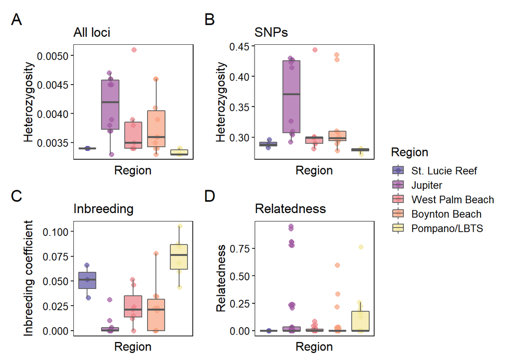

```r
#packages: paletteer, reshape2, patchwork
hetMelt = melt(het, id.vars = c("sample", "Region"), variable.name = "type", value.name = "heterozygosity")

flPal = paletteer_d("rcartocolor::Sunset")[c(7, 6, 4, 3, 1)]

hetTheme = theme(axis.title.x = element_text(color = "black", size = 12),
        axis.text.x = element_blank(),
        axis.ticks.x = element_blank(),
        axis.title.y = element_text(color = "black", size = 12),
        axis.text.y = element_text(color = "black", size = 10),
        axis.ticks.y = element_line(color = "black"),
        legend.position = "right",
        legend.key.size = unit(0.5, 'cm'),
        panel.border = element_rect(color = "black"),
        panel.background = element_rect(fill = "white"),
        plot.background = element_rect(fill = "white"),
        panel.grid.major = element_blank(),
        panel.grid.minor = element_blank())

dodge <- position_dodge(width = 1)

hetPlotAll = ggplot(data = subset(hetMelt, subset = hetMelt$type == "All"),aes(x = Region, y = heterozygosity, fill = Region)) +
  geom_point(aes(color = Region),shape = 21, position = position_jitterdodge(seed = 1, dodge.width = 1), size = 2, alpha = 0.7) +
  geom_boxplot(size = 0.5, alpha = 0.7, position = dodge, color = "gray35", outlier.shape = NA) +
  xlab("Region") +
  ylab("Heterozygosity") +
  ggtitle("All loci") +
  scale_fill_manual(values = flPal) +
  scale_color_manual(values = flPal) +
  theme_bw() +
  hetTheme

hetPlotSnps = ggplot(data = subset(hetMelt, subset = hetMelt$type == "SNPs"),aes(x = Region, y = heterozygosity, fill = Region)) +
  geom_point(aes(color = Region),shape = 21, position = position_jitterdodge(seed = 1, dodge.width = 1), size = 2, alpha = 0.7) +
  geom_boxplot(size = 0.5, alpha = 0.7, position = dodge, color = "gray35", outlier.shape = NA) +
  xlab("Region") +
  ylab("Heterozygosity") +
  ggtitle("SNPs") +
  scale_fill_manual(values = flPal) +
  scale_color_manual(values = flPal) +
  theme_bw() +
  hetTheme

inbreedingPlot = ggplot(data = het, aes(x = Region, y = inbreed, fill = Region)) +
  geom_point(aes(color = Region),shape = 21, position = position_jitterdodge(seed = 1, dodge.width = 1), size = 2, alpha = 0.7) +
  geom_boxplot(size = 0.5, alpha = 0.7, position = dodge, color = "gray35", outlier.shape = NA) +
  xlab("Region") +
  ylab("Inbreeding coefficient") +
  ggtitle("Inbreeding") +
  scale_fill_manual(values = flPal) +
  scale_color_manual(values = flPal) +
  theme_bw() +
  hetTheme

relatePlot = ggplot(data = pastRelate, aes(x = Region, y = relate, fill = Region)) +
  geom_point(aes(color = Region),shape = 21, position = position_jitterdodge(seed = 1, dodge.width = 1), size = 2, alpha = 0.7) +
  geom_boxplot(size = 0.5, alpha = 0.7, position = dodge, color = "gray35", outlier.shape = NA) +
  xlab("Region") +
  ylab("Relatedness") +
  ggtitle("Relatedness") +
  scale_fill_manual(values = flPal) +
  scale_color_manual(values = flPal) +
  theme_bw() +
  hetTheme

hetPlots = ((hetPlotAll | hetPlotSnps) / (inbreedingPlot | relatePlot)) +
  plot_annotation(tag_levels = 'A') +
  plot_layout(guides = "collect")&
  theme(plot.tag = element_text(size = 16),
        legend.title = element_text(size = 12),
        legend.text = element_text(size = 10),
        legend.position = "right")

hetPlots
```

```r
ggsave("figures/heterozygosityPlot.png", plot = hetPlots, width = 22, height = 16, units = "cm", dpi = 300)
ggsave("figures/heterozygosityPlot.pdf", plot = hetPlots, width = 22, height = 16, units = "cm", dpi = 300)
```

#

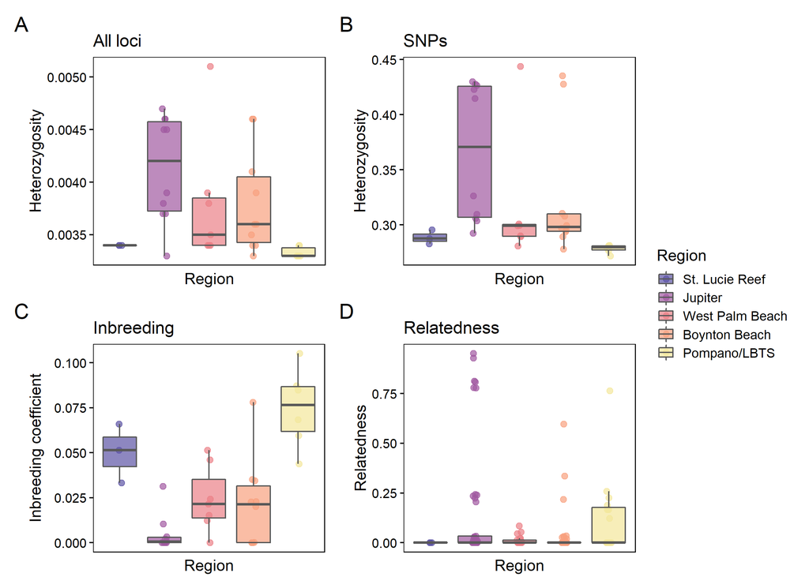

Identifying outlier SNPs, indicative of some type of selection taking place

```r
# packages: tidyverse
bayescan = read.table("C:/Users/erin_/Documents/GitHub/SEFL_Pastreoides_2bRAD/data_files/seflpast.baye_fst.txt",header=T) %>% mutate(loc = rownames(.), out.05 = ifelse(qval < 0.05, 1, 0), out.1 = ifelse(qval < 0.1, 1, 0))
bayescan[bayescan[, 3]<=0.0001, 3] = 0.0001

bayeScEnv = read.table("C:/Users/erin_/Documents/GitHub/SEFL_Pastreoides_2bRAD/data_files/seflpast.bayeS_fst.txt", header=T) %>% filter(qval_g < 0.05) %>% mutate(loc = rownames(.), depthOut = 1) %>% select(loc, depthOut)
bayescan = bayescan %>% left_join(bayeScEnv)
bayescan$depthOut = bayescan$depthOut %>% replace_na(0)
sum(bayescan$out.05)
```

```
## [1] 10
```

```r
sum(bayescan$out.1)
```

```
## [1] 18
```

```r
sum(bayescan$depthOut)
```

```
## [1] 0
```

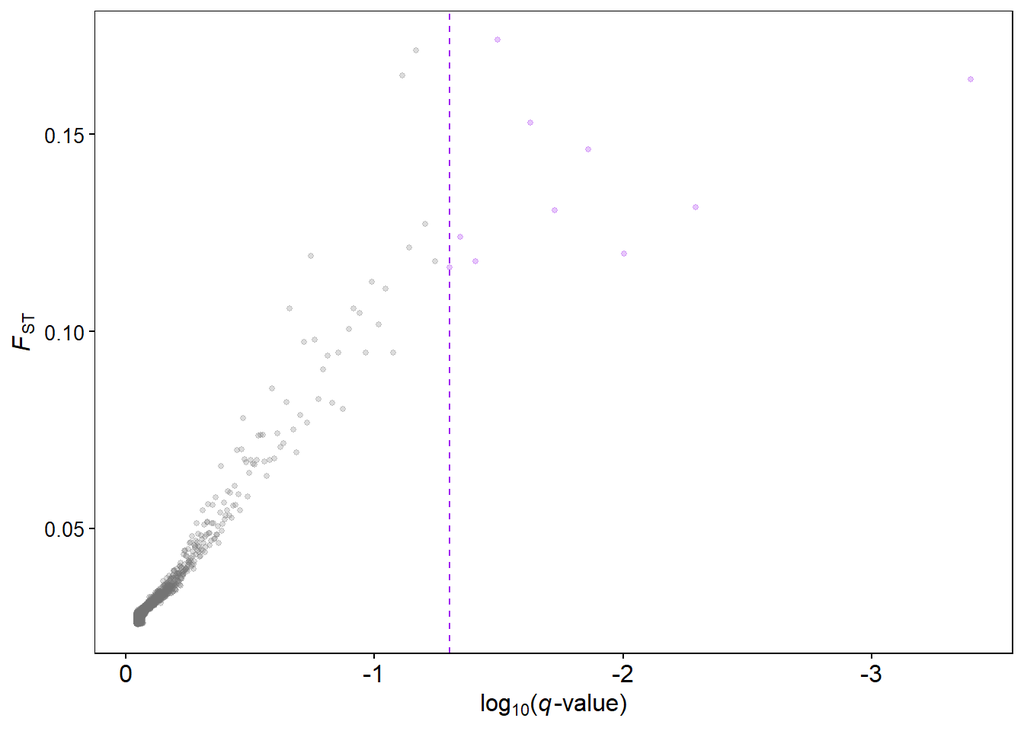

```r
for(i in 1:nrow(bayescan)){
  if(bayescan$depthOut[i] == 1){
    bayescan$out.05[i] = 2
  }
}
bayescanPlotA = ggplot(data = bayescan, aes(x = log10(qval), y = fst, color = as.factor(out.05), alpha = as.factor(out.05))) +
  geom_point(size = 1) +
  geom_vline(xintercept = log10(0.05), linetype = 2, color = "purple") +
  xlab(expression(log[10]*"("*italic("q")*"-value)")) +
  ylab(expression(italic("F")[ST])) +
  scale_x_reverse() +
  scale_color_manual(values = c("grey45", "purple", "pink")) +
  scale_alpha_manual(values = c(0.25, 0.25, 0.5)) +
  theme_bw()

bayescanPlot = bayescanPlotA +
        theme(axis.title.x = element_text(color = "black", size = 12),
        axis.text.x = element_text(color = "black", size = 12),
        axis.ticks.x = element_line(color = "black"),
        axis.title.y = element_text(color = "black", size = 12),
        axis.text.y = element_text(color = "black", size = 10),
        axis.ticks.y = element_line(color = "black"),
        legend.position = "none",
        legend.key.size = unit(0.3, 'cm'),
        panel.border = element_rect(color = "black"),
        panel.background = element_rect(fill = "white"),
        plot.background = element_rect(fill = "white"),
        panel.grid.major = element_blank(),
        panel.grid.minor = element_blank())

bayescanPlot
```

```r
ggsave("C:/Users/erin_/Documents/GitHub/SEFL_Pastreoides_2bRAD/figures/outliers.pdf", plot = bayescanPlot, width = 14, height = 8, units = "cm", dpi = 300)
ggsave("C:/Users/erin_/Documents/GitHub/SEFL_Pastreoides_2bRAD/figures/outliers.png", plot = bayescanPlot, width = 14, height = 8, units = "cm", dpi = 300)
```

Only ten outlier SNPs

P. astreoides isolation by distance

```r
ReplaceLowerOrUpperTriangle = function(m, triangle.to.replace) {
  if (nrow(m) != ncol(m))
    stop("Supplied matrix must be square.")
  if (tolower(triangle.to.replace) == "lower")
    tri = lower.tri(m)
  else if (tolower(triangle.to.replace) == "upper")
    tri = upper.tri(m)
  else
    stop("triangle.to.replace must be set to 'lower' or 'upper'.")
  m[tri] = t(m)[tri]
  return(m)
}
# If triangle.to.replace="lower", replaces the lower triangle of a square matrix with its upper triangle.
# If triangle.to.replace="upper", replaces the upper triangle of a square matrix with its lower triangle.
GeoDistanceInMetresMatrix = function(df.geopoints) {
# Returns a matrix (M) of distances between geographic points. M[i,j] = M[j,i] = Distance between (df.geopoints$lat[i], df.geopoints$lon[i]) and (df.geopoints$lat[j], df.geopoints$lon[j]). The row and column names are given by df.geopoints$name.

  GeoDistanceInMetres = function(g1, g2) {
# Returns a vector of distances. (But if g1$index > g2$index, returns zero.) The 1st value in the returned vector is the distance between g1[[1]] and g2[[1]]. The 2nd value in the returned vector is the distance between g1[[2]] and g2[[2]]. Etc. Each g1[[x]] or g2[[x]] must be a list with named elements "index", "lat" and "lon". E.g. g1 = list(list("index"=1, "lat"=12.1, "lon"=10.1), list("index"=3, "lat"=12.1, "lon"=13.2))

    DistM = function(g1, g2) {
      require("Imap")
      return(ifelse(
        g1$index > g2$index,
        0,
        gdist(lat.1 = g1$lat, lon.1 = g1$lon, lat.2 = g2$lat, lon.2 = g2$lon, units = "m")))
    }
    return(mapply(DistM, g1, g2))
  }

  n.geopoints = nrow(df.geopoints)

# The index column is used to ensure we only do calculations for the upper triangle of points
  df.geopoints$index = 1:n.geopoints

# Create a list of lists
  list.geopoints = by(df.geopoints[, c("index", "lat", "lon")], 1:n.geopoints, function(x) {
    return(list(x))
  })

# Get a matrix of distances (in metres)
  mat.distances = ReplaceLowerOrUpperTriangle(outer(list.geopoints, list.geopoints, GeoDistanceInMetres), "lower")

# Set the row and column names
  rownames(mat.distances) = df.geopoints$name
  colnames(mat.distances) = df.geopoints$name
  return(mat.distances)}
```

And now that we’ve calculated the geographic distance between them, can run the Mantel test Mantel isolation by distance test between individuals Using IBS and geographic distance matrices

```r
#packages: ade4, reshape2, paletteer
pastIBS = read.table("C:/Users/erin_/Documents/GitHub/SEFL_Pastreoides_2bRAD/data_files/pastNoClones.ibsMat")%>% as.matrix() %>% as.dist(diag = FALSE)
coords = read.csv("C:/Users/erin_/Documents/GitHub/SEFL_Pastreoides_2bRAD/data_files/poritesastreoidesMetaData_clonesremoved.csv") %>% select(name = tube_id, lat = site_lat, lon = site_long)
pastGeo = as.dist(GeoDistanceInMetresMatrix(coords)/1000, diag = FALSE)
set.seed(694)
seflPastMantelDist = mantel.randtest(pastIBS, pastGeo, nrepet = 9999)
seflPastMantelDist
```

```
## Monte-Carlo test
## Call: mantel.randtest(m1 = pastIBS, m2 = pastGeo, nrepet = 9999)
##
## Observation: 0.2567754
##
## Based on 9999 replicates
## Simulated p-value: 1e-04
## Alternative hypothesis: greater
##
##      Std.Obs  Expectation     Variance
## 5.9570370194 0.0001279032 0.0018561517
```

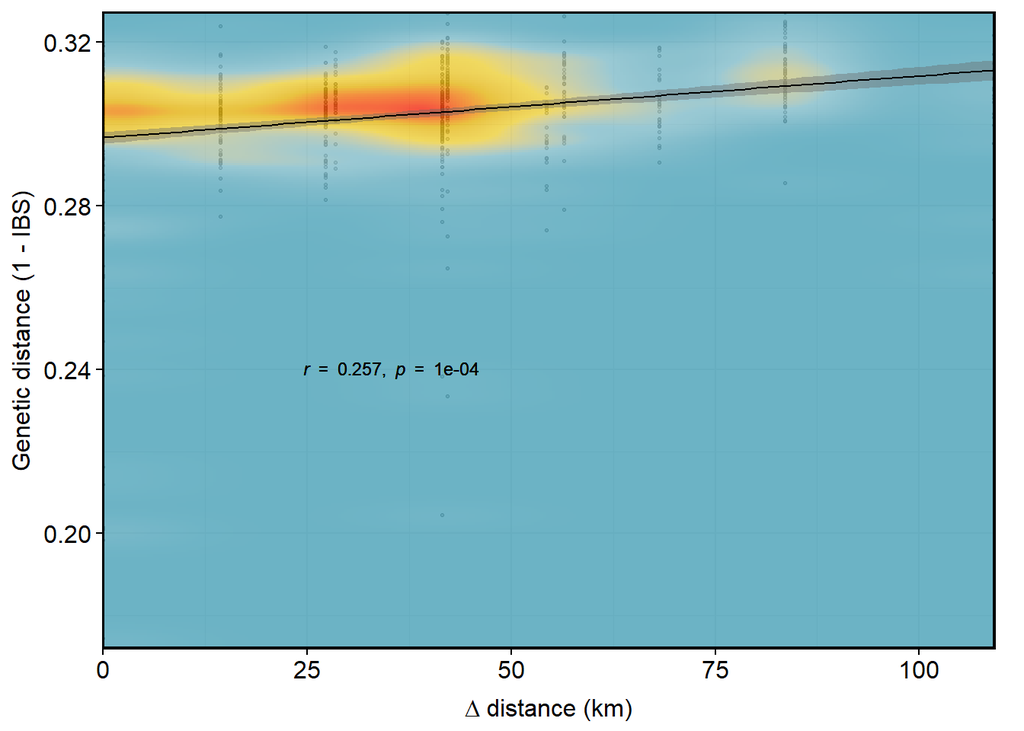

```r
#SIGNIFICANT
##MAKING FIGURE
mantelObsDist = round(seflPastMantelDist$obs, 3)
mantelPDist = seflPastMantelDist$pvalue

pastIBSdist =  melt(as.matrix(pastIBS), varnames = c("row", "col"), value.name = "ibs")

pastIBSdist = pastIBSdist[pastIBSdist$row != pastIBSdist$col,]

pastDist = melt(as.matrix(pastGeo), varnames = c("row", "col"), value.name = "distance")

pastDist = pastDist[pastDist$row != pastDist$col,]
snpMantelDistF = data.frame(cbind(pastIBSdist$ibs, pastDist$distance))
colnames(snpMantelDistF) = c("ibs", "distance")

pastIBSdistMantelA = ggplot(data = snpMantelDistF, aes(x = distance, y = ibs)) +
  scale_fill_gradientn(colors = paletteer_d("wesanderson::Zissou1")) +
  geom_point(shape = 21, fill = "gray40", alpha = 0.25, size = 0.5) +
  stat_density_2d(aes(fill = stat(density)), n = 300, contour = FALSE, geom = "raster", alpha = 0.75) +
  geom_smooth(method = lm, col = "black", fill = "gray40", fullrange = TRUE, size = 0.5) +
  scale_x_continuous(expand = c(0,0)) +
  scale_y_continuous(expand = c(0,0)) +
  annotate(geom = "text", x = 35, y = 0.24, label = bquote(~italic(r)~" = "~.(mantelObsDist)*", "~italic(p)~" = "~.(mantelPDist)), size = 3) +
  labs(x = expression(paste(Delta," distance (km)")), y = "Genetic distance (1 - IBS)") +
  theme_bw()
pastIBSdistMantel = pastIBSdistMantelA + theme(
  axis.title.x = element_text(size = 12, color = "black"),
  axis.text.x = element_text(size = 12, color = "black"),
  axis.ticks.x = element_line(color = "black"),
  axis.line.x = element_blank(),
  axis.title.y = element_text(size = 12, color = "black"),
  axis.text.y = element_text(size = 12, color = "black"),
  axis.ticks.y = element_line(color = "black"),
  axis.line.y = element_blank(),
  panel.border = element_rect(size = 1.2, color = "black"),
  plot.margin = margin(0.2,0.5,0.1,0.1, unit = "cm"),
  legend.position = "none")

pastIBSdistMantel
```

```r
ggsave("C:/Users/erin_/Documents/GitHub/SEFL_Pastreoides_2bRAD/figures/distance_mantelPlot.tiff", plot = pastIBSdistMantel, width = 12, height = 7, units = "cm", dpi = 300)
ggsave("C:/Users/erin_/Documents/GitHub/SEFL_Pastreoides_2bRAD/figures/distance_mantelPlot.pdf", plot = pastIBSdistMantel, width = 12, height = 7, units = "cm", dpi = 300)
ggsave("C:/Users/erin_/Documents/GitHub/SEFL_Pastreoides_2bRAD/figures/distance_mantelPlot.png", plot = pastIBSdistMantel, width = 12, height = 7, units = "cm", dpi = 300)
```

#

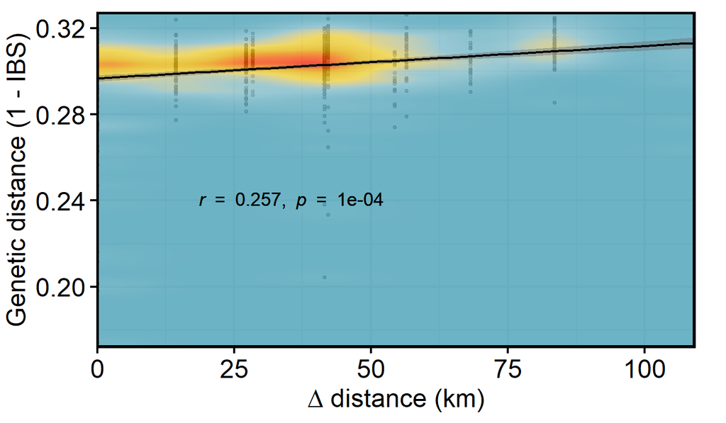

Mantel test across depths Using IBS and depth distance matrices

```r
# packages: tidyverse, ade4, reshape2, paletteer
pastIBS = read.table("C:/Users/erin_/Documents/GitHub/SEFL_Pastreoides_2bRAD/data_files/pastNoClones.ibsMat")%>% as.matrix() %>% as.dist(diag = FALSE)
pastDepths = read.csv("C:/Users/erin_/Documents/GitHub/SEFL_Pastreoides_2bRAD/data_files/poritesastreoidesMetaData_clonesremoved.csv") %>% select(name = tube_id, collection_depth_m) %>% dist(method = "maximum")
set.seed(694)
seflpastMantel = mantel.randtest(pastIBS, pastDepths, nrepet = 9999)
seflpastMantel
```

```
## Monte-Carlo test
## Call: mantel.randtest(m1 = pastIBS, m2 = pastDepths, nrepet = 9999)
##
## Observation: 0.2341118
##
## Based on 9999 replicates
## Simulated p-value: 1e-04
## Alternative hypothesis: greater
##
##       Std.Obs   Expectation      Variance
##  5.6023266492 -0.0002762516  0.0017503863
```

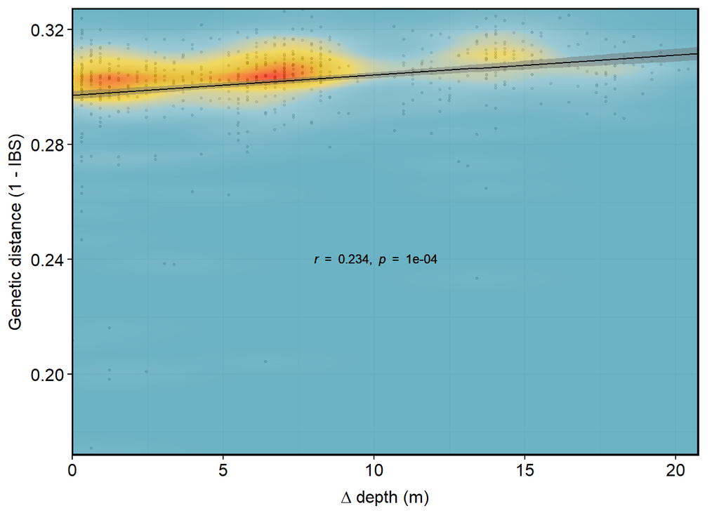

```r
mantelObs = round(seflpastMantel$obs, 3)
mantelP = seflpastMantel$pvalue

pastIBSdist =  melt(as.matrix(pastIBS), varnames = c("row", "col"), value.name = "ibs")
pastIBSdist = pastIBSdist[pastIBSdist$row != pastIBSdist$col,]
pastDepth = melt(as.matrix(pastDepths), varnames = c("row", "col"), value.name = "depth")
pastDepth = pastDepth[pastDepth$row != pastDepth$col,]
snpMantelDF = data.frame(cbind(pastIBSdist$ibs, pastDepth$depth))
colnames(snpMantelDF) = c("ibs", "depth")

#start building plot
pastIBSdepthMantelA = ggplot(data = snpMantelDF, aes(x = depth, y = ibs)) + scale_fill_gradientn(colors = paletteer_d("wesanderson::Zissou1")) +
  geom_point(shape = 21, fill = "gray40", alpha = 0.25, size = 0.5) +
  stat_density_2d(aes(fill = stat(density)), n = 300, contour = FALSE, geom = "raster", alpha = 0.75) +
  geom_smooth(method = lm, col = "black", fill = "gray40", fullrange = TRUE, size = 0.5) +
  scale_x_continuous(expand = c(0,0)) +
  scale_y_continuous(expand = c(0,0)) +
  annotate(geom = "text", x = 10, y = 0.24, label = bquote(~italic(r)~" = "~.(mantelObs)*", "~italic(p)~" = "~.(mantelP)), size = 3) +
  labs(x = expression(paste(Delta," depth (m)")), y = "Genetic distance (1 - IBS)") +
  theme_bw()
pastIBSdepthMantel = pastIBSdepthMantelA + theme(
  axis.title.x = element_text(size = 12, color = "black"),
  axis.text.x = element_text(size = 12, color = "black"),
  axis.ticks.x = element_line(color = "black"),
  axis.line.x = element_blank(),
  axis.title.y = element_text(size = 12, color = "black"),
  axis.text.y = element_text(size = 12, color = "black"),
  axis.ticks.y = element_line(color = "black"),
  axis.line.y = element_blank(),
  panel.border = element_rect(size = 1.2, color = "black"),
  plot.margin = margin(0.2,0.5,0.1,0.1, unit = "cm"),
  legend.position = "none")

pastIBSdepthMantel
```

```r
ggsave("C:/Users/erin_/Documents/GitHub/SEFL_Pastreoides_2bRAD/figures/depth_mantelPlot.tiff", plot = pastIBSdepthMantel, width = 12, height = 7, units = "cm", dpi = 300)
ggsave("C:/Users/erin_/Documents/GitHub/SEFL_Pastreoides_2bRAD/figures/depth_mantelPlot.pdf", plot = pastIBSdepthMantel, width = 12, height = 7, units = "cm", dpi = 300)
ggsave("C:/Users/erin_/Documents/GitHub/SEFL_Pastreoides_2bRAD/figures/depth_mantelPlot.png", plot = pastIBSdepthMantel, width = 12, height = 7, units = "cm", dpi = 300)
```

ADMIXTURE plot Population structure plot from NGSadmix/CLUMPAK results. Based on most probable values for K

```r
# packages: paletteer, tidyverse, reshape2
kColPal3 = paletteer_c("viridis::viridis", n = 3)
kColPal7 = paletteer_c("viridis::viridis", n = 7)

flPal = paletteer_d("rcartocolor::Sunset")[c(7, 6, 4, 3, 1)]

admixpops = read.csv("C:/Users/erin_/Documents/GitHub/SEFL_Pastreoides_2bRAD/data_files/poritesastreoidesMetaData_clonesremoved.csv") %>% select("sample" = tube_id, "Region" = region)

clumpp3 = read.table("data_files/pastClumppK3", header = FALSE)
clumpp7 = read.table("data_files/pastClumppK7", header = FALSE)
clumpp3$V1 = admixpops$sample
clumpp7$V1 = admixpops$sample

seflPastAdmix = admixpops %>% left_join(clumpp3[,c(1,6:8)], by = c("sample" = "V1")) %>%
  left_join(clumpp7[,c(1, 6:12)], by = c("sample" = "V1")) %>% rename("cluster3.1" = "V6.x", "cluster3.2" = "V7.x", "cluster3.3" = "V8.x","cluster7.1" = "V6.y", "cluster7.2" = "V7.y", "cluster7.3" = "V8.y", "cluster7.4" = "V9", "cluster7.5" = "V10", "cluster7.6" = "V11", "cluster7.7" = "V12")

seflPastAdmix$Region = factor(seflPastAdmix$Region)
seflPastAdmix$Region = factor(seflPastAdmix$Region, levels(seflPastAdmix$Region)[c(4, 2, 5, 1, 3)])

levels(seflPastAdmix$Region)[1] = "St. Lucie"

seflPastAdmix = arrange(seflPastAdmix, Region, -cluster3.1)
popCounts = seflPastAdmix %>% group_by(Region) %>% summarize(n = n())

popCounts
```

```
## # A tibble: 5 x 2
##   Region              n
##   <fct>           <int>
## 1 St. Lucie           3
## 2 Jupiter            10
## 3 West Palm Beach     7
## 4 Boynton Beach      10
## 5 Pompano/LBTS        6
```

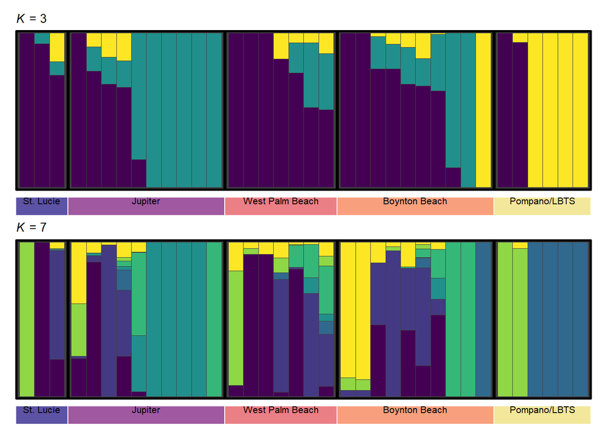

```r
popCountList = reshape2::melt(lapply(popCounts$n,function(x){c(1:x)}))
seflPastAdmix$ord = popCountList$value

seflPastAdmixMelt = melt(seflPastAdmix, id.vars=c("sample", "Region", "ord"), variable.name="Ancestry", value.name="Fraction")

seflPastAdmixMelt$Ancestry = factor(seflPastAdmixMelt$Ancestry)
seflPastAdmixMelt$Ancestry = factor(seflPastAdmixMelt$Ancestry, levels = rev(levels(seflPastAdmixMelt$Ancestry)))

popAnno = data.frame(x1 = c(0.3, 0.3, 0.3, 0.3, 0.3), x2 = c(3.7, 10.7, 7.7, 10.7, 6.7),
                     y1 = -0.12, y2 = -0.12, sample = NA, Ancestry = NA, ord  = NA, Fraction = NA,
                     Region= c("St. Lucie", "Jupiter", "West Palm Beach", "Boynton Beach", "Pompano/LBTS"))

popAnno$Region = factor(popAnno$Region)
popAnno$Region = factor(popAnno$Region, levels = levels(popAnno$Region)[c(4, 2, 5, 1, 3)])

admixTheme = theme_bw()+
  theme(plot.title = element_text(hjust = 0, size = 10),
  panel.grid = element_blank(),
  panel.background = element_rect(fill = "gray25", colour = "gray25"),
  panel.border = element_rect(fill = NA, color = "black", size = 1, linetype = "solid"),
  panel.spacing.x = grid:::unit(0.05, "lines"),
  panel.spacing.y = grid:::unit(0.05, "lines"),
  axis.text.x = element_blank(),
  axis.text.y = element_blank(),
  axis.ticks.x = element_blank(),
  axis.ticks.y = element_blank(),
  axis.title = element_blank(),
  strip.background.x = element_blank(),
  strip.background.y = element_blank(),
  strip.text = element_text(size = 8),
  strip.text.y.left = element_text(size = 10, angle = 90),
  strip.text.x.bottom = element_text(vjust = -.1, color = "black"),
  legend.key = element_blank(),
  legend.position = "none",
  legend.title = element_text(size = 8))

admixPlotK3A = ggplot(data = subset(seflPastAdmixMelt, subset = seflPastAdmixMelt$Ancestry %in% c("cluster3.1", "cluster3.2", "cluster3.3")), aes(x = ord, y = Fraction, fill = Ancestry, order = sample)) +
    geom_segment(data = popAnno, aes(x = x1, xend = x2, y = y1, yend = y2, color = Region), size = 7) +
  geom_bar(stat = "identity", position = "fill", width = 1, colour = "grey25", size = 0.2) +
  facet_grid(.~ Region, scales = "free", switch = "both", space = "free") +
  scale_x_discrete(expand = c(0, 0)) +
  scale_y_continuous(expand = c(0.001, 0.001)) +
  scale_fill_manual(values = kColPal3) +
  scale_color_manual(values = flPal) +
  ggtitle(expression(paste(italic("K")," = 3", sep =""))) +
  coord_cartesian(ylim = c(-0.01, 1.01), clip = "off")

admixPlotK3 = admixPlotK3A + admixTheme

admixPlotK7A = ggplot(data = subset(seflPastAdmixMelt, subset = !(seflPastAdmixMelt$Ancestry %in% c("cluster3.1", "cluster3.2", "cluster3.3"))), aes(x = ord, y = Fraction, fill = Ancestry, order = sample)) +
    geom_segment(data = popAnno, aes(x = x1, xend = x2, y = y1, yend = y2, color = Region), size = 7) +
  geom_bar(stat = "identity", position = "fill", width = 1, colour = "grey25", size = 0.2) +
  facet_grid(.~ Region, scales = "free", switch = "both", space = "free") +
  scale_x_discrete(expand = c(0, 0)) +
  scale_y_continuous(expand = c(0.001, 0.001)) +
  scale_fill_manual(values = kColPal7) +
  scale_color_manual(values = flPal) +
  ggtitle(expression(paste(italic("K")," = 7", sep =""))) +
  coord_cartesian(ylim = c(-.01, 1.01), clip = "off")

admixPlotK7 = admixPlotK7A + admixTheme
# admixPlotK4 = admixPlotK4A + admixTheme +
#   theme(strip.text.y.left = element_blank())

admixPlot = (admixPlotK3 / admixPlotK7)

admixPlot
```

```r
ggsave("C:/Users/erin_/Documents/GitHub/SEFL_Pastreoides_2bRAD/figures/admixturePlot.png", plot = admixPlot, width = 15, height = 10, units = "cm", dpi = 300)
ggsave("C:/Users/erin_/Documents/GitHub/SEFL_Pastreoides_2bRAD/figures/admixturePlot.eps", plot = admixPlot, width = 15, height = 10, units = "cm", dpi = 300)
ggsave("C:/Users/erin_/Documents/GitHub/SEFL_Pastreoides_2bRAD/figures/admixturePlot.eps", plot = admixPlot, width = 15, height = 10, units = "cm", dpi = 300)
```

```r
# packages: tidyverse, reshape2, RColorBrewer, paletteer
# read in sample metadata with clones, remove technical replicates
popDataClones = read.csv("C:/Users/erin_/Documents/GitHub/SEFL_Pastreoides_2bRAD/data_files/poritesastreoidesMetaData.csv") [-c(27, 28, 46, 47, 79, 80),] %>% select("sample" = tube_id, "pop" = region)
#treat populations as a factor & order them North-->South
popDataClones$pop = factor(popDataClones$pop)
popDataClones$pop = factor(popDataClones$pop, levels = levels(popDataClones$pop)[c(4, 2, 5, 1, 3)])
#read in zoox reads data with clones incl, technical replicates removed
zoox = read.delim("C:/Users/erin_/Documents/GitHub/SEFL_Pastreoides_2bRAD/data_files/zooxReads_withclones_techrepsrem", header = FALSE, check.names = FALSE)
head(zoox)
```

```
##                       V1   V2
## 1 P001.trim.zoox.bt2.bam   NA
## 2                   chr1 4548
## 3                   chr2 6313
## 4                   chr3 8524
## 5                   chr4 8700
## 6                   chr5  136
```

```r
zoox$V2[is.na(zoox$V2)] <- as.character(zoox$V1[is.na(zoox$V2)])
zoox$V1 = gsub("P.*", "chr", zoox$V1)
zoox$V2 = gsub(".trim.*", "", zoox$V2)
zoox = zoox %>% filter(zoox$V1 != "*")

zooxLst = split(zoox$V2, as.integer(gl(length(zoox$V2), 20, length(zoox$V2))))

zooxMaps = NULL

for(i in zooxLst){
  zooxMaps = rbind(zooxMaps, data.frame(t(i)))
}

colnames(zooxMaps) = c("sample", zoox$V1[c(2:20)])

for(i in c(2:20)){
  zooxMaps[,i] = as.numeric(zooxMaps[,i])
  }
str(zooxMaps)
```

```
## 'data.frame':    87 obs. of  20 variables:
##  $ sample: chr  "P001" "P002" "P003" "P004" ...
##  $ chr1  : num  4548 1056 2410 4873 2569 ...
##  $ chr2  : num  6313 1554 2831 5685 3194 ...
##  $ chr3  : num  8524 2218 3585 6963 3748 ...
##  $ chr4  : num  8700 2079 3334 6667 3515 ...
##  $ chr5  : num  136 39 79 158 70 99 5 104 183 35 ...
##  $ chr6  : num  32 11 69 122 54 99 47 49 81 25 ...
##  $ chr7  : num  33 5 42 69 27 56 30 32 74 17 ...
##  $ chr8  : num  25 4 42 100 56 82 53 48 88 17 ...
##  $ chr9  : num  75 26 42 65 28 42 54 43 71 23 ...
##  $ chr10 : num  20 10 6 18 16 9 972 91 31 18 ...
##  $ chr11 : num  17 7 30 45 22 ...
##  $ chr12 : num  19 8 22 35 16 ...
##  $ chr13 : num  32 6 39 98 45 ...
##  $ chr14 : num  159 137 187 209 180 ...
##  $ chr15 : num  13 0 8 15 15 12 217 33 23 11 ...
##  $ chr16 : num  8 3 4 25 10 17 12 23 12 10 ...
##  $ chr17 : num  8 6 18 44 19 23 17 25 47 23 ...
##  $ chr18 : num  1 0 1 2 4 4 1 9 2 1 ...
##  $ chr19 : num  2 2 0 2 2 0 0 2 3 0 ...
```

```r
zooxMaps$Symbiodinium = rowSums(zooxMaps[2:6])
zooxMaps$Breviolum = rowSums(zooxMaps[7:10])
zooxMaps$Cladocopium = rowSums(zooxMaps[11:16])
zooxMaps$Durusdinium = rowSums(zooxMaps[17:20])

zooxMaps = zooxMaps[,c(1, 21:24)]
zooxProp = zooxMaps

zooxProp$sum = apply(zooxProp[, c(2:length(zooxProp[1,]))], 1, function(x) {
sum(x, na.rm = T)
})

#turn them into proportions
zooxProp = cbind(zooxProp$sample, (zooxProp[, c(2:(ncol(zooxProp)-1))]
/ zooxProp$sum))
colnames(zooxProp)[1] = "sample"
head(zooxProp)
```

```
##   sample Symbiodinium   Breviolum Cladocopium  Durusdinium
## 1   P001    0.9845107 0.005756149 0.009070295 0.0006628292
## 2   P002    0.9686236 0.006414726 0.023427695 0.0015339562
## 3   P003    0.9599969 0.015295317 0.022903757 0.0018040631
## 4   P004    0.9663028 0.014129788 0.016669974 0.0028974003
## 5   P005    0.9636497 0.012141280 0.021633554 0.0025754231
## 6   P006    0.9705790 0.012474849 0.014978761 0.0019673597
```

```r
apply(zooxProp[, c(2:(ncol(zooxProp)))], 1, function(x) {
sum(x, na.rm = T)
})
```

```
##  [1] 1 1 1 1 1 1 1 1 1 1 1 1 1 1 1 1 1 1 1 1 1 1 1 1 1 1 1 1 1 1 1 1 1 1 1 1 1 1
## [39] 1 1 1 1 1 1 1 1 1 1 1 1 1 1 1 1 1 1 1 1 1 1 1 1 1 1 1 1 1 1 1 1 1 1 1 1 1 1
## [77] 1 1 1 1 1 1 1 1 1 1 1
```

```r
#bind it to metadata
dfZoox = popDataClones %>% left_join(zooxProp)
dfZoox$pop = as.factor(dfZoox$pop)

# setting up for plotting
dfZoox = dfZoox[order(dfZoox$pop),]
sampleCounts = plyr::count(dfZoox, c('pop'))
meltedList = reshape2::melt(lapply(sampleCounts$freq,function(x){c(1:x)}))
dfZoox$barPlotOrder = meltedList$value
dfZoox = dfZoox[c(1,ncol(dfZoox),2:(ncol(dfZoox)-1))]
zDat = melt(dfZoox, id.vars = c("sample", "pop", "barPlotOrder"), variable.name = "Symbiont", value.name = "Fraction")

# colors
colPalZoox = brewer.pal(4, "BrBG")
names(colPalZoox) = levels(zDat$Symbiont)

# plotting
colPalZoox = c("#247EA3", "#FFBF46", "#6A9FA1", "Purple3")
flPal = paletteer_d("rcartocolor::Sunset")[c(7, 6, 4, 3, 1)]

popAnno = data.frame(x1 = c(0.5, 0.5, 0.5, 0.5, 0.5), x2 = c(30.5, 15.5, 13.5, 14.5, 15.5),
                     y1 = -0.065, y2 = -0.065, pop = c("St. Lucie Reef", "Jupiter", "West Palm Beach", "Boynton Beach", "Pompano/LBTS"))

popAnno$pop = factor(popAnno$pop)
popAnno$pop = factor(popAnno$pop, levels = levels(popAnno$pop)[c(4, 2, 5, 1, 3)])

dfZoox = zDat %>% left_join(popAnno, by = "pop")

zooxSNPA = ggplot(data = dfZoox, aes(x = barPlotOrder, y = Fraction, fill = Symbiont, order = barPlotOrder)) +
  geom_bar(stat = "identity", position = "stack", colour = "grey25", width = 1, size = 0.2) +
  xlab("Population") +
  scale_x_discrete(expand = c(0.001, 0.001)) +
  scale_y_continuous(expand = c(-.001, -0.001)) +
  scale_color_manual(values = flPal) +
  geom_segment(aes(x = x1, xend = x2, y = y1, yend = y2, color = pop), size = 7) +
  scale_fill_manual(values = colPalZoox, name = "Symbiodiniaceae genus") +
  coord_cartesian(ylim = c(-.01,1.01), clip = "off") +
  facet_grid(~ pop, drop = TRUE, space = "free", scales = "free", switch = "both") +
  guides(color = "none") +
  theme_bw()

zooxSNP = zooxSNPA + theme(plot.title = element_text(),
  panel.grid = element_blank(),
  panel.background = element_rect(fill = "gray25", colour = "grey25"),
  panel.border = element_rect(fill = NA, color = "black", size = 1, linetype = "solid"),
  panel.spacing.x = grid:::unit(0.05, "lines"),
  panel.spacing.y = grid:::unit(0.05, "lines"),
  axis.text.x = element_blank(),
  axis.text.y = element_blank(),
  axis.ticks.x = element_blank(),
  axis.ticks.y = element_blank(),
  axis.title = element_blank(),
  strip.background.x = element_blank(),
  strip.background.y = element_blank(),
  strip.text = element_text(size = 10),
  strip.text.y.left = element_text(size = 10, angle = 90),
  strip.text.x.bottom = element_text(vjust = -.05, color = "black"),
  legend.key.size = unit(0.75, "line"),
  legend.title = element_text(size = 10),
  legend.text = element_text(size = 8),
  legend.key = element_blank(),
  legend.position = "bottom")

# zooxSNP figure with clones

ggsave("C:/Users/erin_/Documents/GitHub/SEFL_Pastreoides_2bRAD/figures/zooxSNP.png", plot = zooxSNP, width = 20, height = 8, units = "cm", dpi = 300)
ggsave("C:/Users/erin_/Documents/GitHub/SEFL_Pastreoides_2bRAD/figures/zooxSNP.eps", plot = zooxSNP, width = 20, height = 8, units = "cm", dpi = 300)
ggsave("C:/Users/erin_/Documents/GitHub/SEFL_Pastreoides_2bRAD/figures/zooxSNP.tiff", plot = zooxSNP, width = 20, height = 8, units = "cm", dpi = 300)
```

```r
#read in sample metadata without clones
popData = read.csv("C:/Users/erin_/Documents/GitHub/SEFL_Pastreoides_2bRAD/data_files/poritesastreoidesMetaData_clonesremoved.csv") %>% select("sample" = tube_id, "pop" = region_short)
#treat populations as a factor & order them North-->South
popData$pop = factor(popData$pop)
popData$pop = factor(popData$pop, levels = levels(popData$pop)[c(4, 2, 5, 1, 3)])
#read in zoox reads data with clones incl, technical replicates removed
#changed 28-1 to 28-2 to match metadata, other 28- reps were missing, same for 77-1 to 77-3
zoox = read.delim("C:/Users/erin_/Documents/GitHub/SEFL_Pastreoides_2bRAD/data_files/zooxReads_withoutclonesortechreps", header = FALSE, check.names = FALSE)
head(zoox)
```

```
##                       V1   V2
## 1 P002.trim.zoox.bt2.bam   NA
## 2                   chr1 1056
## 3                   chr2 1554
## 4                   chr3 2218
## 5                   chr4 2079
## 6                   chr5   39
```

```r
zoox$V2[is.na(zoox$V2)] <- as.character(zoox$V1[is.na(zoox$V2)])
zoox$V1 = gsub("P.*", "chr", zoox$V1)
zoox$V2 = gsub(".trim.*", "", zoox$V2)
zoox = zoox %>% filter(zoox$V1 != "*")
zooxLst = split(zoox$V2, as.integer(gl(length(zoox$V2), 20, length(zoox$V2))))
zooxMaps = NULL
for(i in zooxLst){
  zooxMaps = rbind(zooxMaps, data.frame(t(i)))
}
colnames(zooxMaps) = c("sample", zoox$V1[c(2:20)])
for(i in c(2:20)){
  zooxMaps[,i] = as.numeric(zooxMaps[,i])
  }
str(zooxMaps)
```

```
## 'data.frame':    36 obs. of  20 variables:
##  $ sample: chr  "P002" "P003" "P004" "P006" ...
##  $ chr1  : num  1056 2410 4873 4258 3007 ...
##  $ chr2  : num  1554 2831 5685 5217 3619 ...
##  $ chr3  : num  2218 3585 6963 6278 4245 ...
##  $ chr4  : num  2079 3334 6667 5855 4117 ...
##  $ chr5  : num  39 79 158 99 104 183 35 0 91 50 ...
##  $ chr6  : num  11 69 122 99 49 81 25 37 103 38 ...
##  $ chr7  : num  5 42 69 56 32 74 17 19 58 30 ...
##  $ chr8  : num  4 42 100 82 48 88 17 57 72 42 ...
##  $ chr9  : num  26 42 65 42 43 71 23 75 47 15 ...
##  $ chr10 : num  10 6 18 9 91 31 18 716 31 13 ...
##  $ chr11 : num  7 30 45 28 36 34 12 1050 27 11 ...
##  $ chr12 : num  8 22 35 20 25 22 5 976 36 16 ...
##  $ chr13 : num  6 39 98 65 42 58 29 989 58 31 ...
##  $ chr14 : num  137 187 209 201 182 215 150 943 184 151 ...
##  $ chr15 : num  0 8 15 12 33 23 11 139 18 20 ...
##  $ chr16 : num  3 4 25 17 23 12 10 21 20 5 ...
##  $ chr17 : num  6 18 44 23 25 47 23 25 27 23 ...
##  $ chr18 : num  0 1 2 4 9 2 1 2 3 1 ...
##  $ chr19 : num  2 0 2 0 2 3 0 0 1 1 ...
```

```r
zooxMaps$Symbiodinium = rowSums(zooxMaps[2:6])
zooxMaps$Breviolum = rowSums(zooxMaps[7:10])
zooxMaps$Cladocopium = rowSums(zooxMaps[11:16])
zooxMaps$Durusdinium = rowSums(zooxMaps[17:20])

zooxMaps = zooxMaps[,c(1, 21:24)]
zooxProp = zooxMaps

zooxProp$sum = apply(zooxProp[, c(2:length(zooxProp[1,]))], 1, function(x) {
sum(x, na.rm = T)
})

#turn them into proportions
zooxProp = cbind(zooxProp$sample, (zooxProp[, c(2:(ncol(zooxProp)-1))]
/ zooxProp$sum))
colnames(zooxProp)[1] = "sample"
head(zooxProp)
```

```
##   sample Symbiodinium   Breviolum Cladocopium Durusdinium
## 1   P002    0.9686236 0.006414726  0.02342769 0.001533956
## 2   P003    0.9599969 0.015295317  0.02290376 0.001804063
## 3   P004    0.9663028 0.014129788  0.01666997 0.002897400
## 4   P006    0.9705790 0.012474849  0.01497876 0.001967360
## 5   P008    0.9593186 0.010933130  0.02599797 0.003750318
## 6   P009    0.9772060 0.009405140  0.01147187 0.001916971
```

```r
apply(zooxProp[, c(2:(ncol(zooxProp)))], 1, function(x) {
sum(x, na.rm = T)
})
```

```
##  [1] 1 1 1 1 1 1 1 1 1 1 1 1 1 1 1 1 1 1 1 1 1 1 1 1 1 1 1 1 1 1 1 1 1 1 1 1
```

```r
#bind it to metadata
dfZoox = popData %>% left_join(zooxProp)
dfZoox$pop = as.factor(dfZoox$pop)

# setting up for plotting
dfZoox = dfZoox[order(dfZoox$pop),]
sampleCounts = plyr::count(dfZoox, c('pop'))
meltedList = reshape2::melt(lapply(sampleCounts$freq,function(x){c(1:x)}))
dfZoox$barPlotOrder = meltedList$value
dfZoox = dfZoox[c(1,ncol(dfZoox),2:(ncol(dfZoox)-1))]
zDat = melt(dfZoox, id.vars = c("sample", "pop", "barPlotOrder"), variable.name = "Symbiont", value.name = "Fraction")

colPalZoox = brewer.pal(4, "BrBG")
names(colPalZoox) = levels(zDat$Symbiont)

# plotting
colPalZoox = c("#247EA3", "#FFBF46", "#6A9FA1", "Purple3")
flPal = paletteer_d("rcartocolor::Sunset")[c(7, 6, 4, 3, 1)]

popAnno = data.frame(x1 = c(0.5, 0.5, 0.5, 0.5, 0.5), x2 = c(3.5, 10.5, 7.5, 10.5, 6.5),
                     y1 = -0.065, y2 = -0.065, pop = c("SLR", "Jupiter", "West Palm Beach", "Boynton Beach", "Pompano/LBTS"))

popAnno$pop = factor(popAnno$pop)
popAnno$pop = factor(popAnno$pop, levels = levels(popAnno$pop)[c(4, 2, 5, 1, 3)])

dfZoox = zDat %>% left_join(popAnno, by = "pop")

zooxSNPA = ggplot(data = dfZoox, aes(x = barPlotOrder, y = Fraction, fill = Symbiont, order = barPlotOrder)) +
  geom_bar(stat = "identity", position = "stack", colour = "grey25", width = 1, size = 0.2) +
  xlab("Population") +
  scale_x_discrete(expand = c(0.001, 0.001)) +
  scale_y_continuous(expand = c(-.001, -0.001)) +
  scale_color_manual(values = flPal) +
  geom_segment(aes(x = x1, xend = x2, y = y1, yend = y2, color = pop), size = 7) +
  scale_fill_manual(values = colPalZoox, name = "Symbiodiniaceae genus") +
  coord_cartesian(ylim = c(-.01,1.01), clip = "off") +
  facet_grid(~ pop, drop = TRUE, space = "free", scales = "free", switch = "both") +
  guides(color = "none") +
  theme_bw()

zooxSNP = zooxSNPA + theme(plot.title = element_text(),
  panel.grid = element_blank(),
  panel.background = element_rect(fill = "gray25", colour = "grey25"),
  panel.border = element_rect(fill = NA, color = "black", size = 1, linetype = "solid"),
  panel.spacing.x = grid:::unit(0.05, "lines"),
  panel.spacing.y = grid:::unit(0.05, "lines"),
  axis.text.x = element_blank(),
  axis.text.y = element_blank(),
  axis.ticks.x = element_blank(),
  axis.ticks.y = element_blank(),
  axis.title = element_blank(),
  strip.background.x = element_blank(),
  strip.background.y = element_blank(),
  strip.text = element_text(size = 10),
  strip.text.y.left = element_text(size = 10, angle = 90),
  strip.text.x.bottom = element_text(vjust = -.05, color = "black"),
  legend.key.size = unit(0.75, "line"),
  legend.title = element_text(size = 10),
  legend.text = element_text(size = 8),
  legend.key = element_blank(),
  legend.position = "bottom")

# zooxSNP without clones

ggsave("C:/Users/erin_/Documents/GitHub/SEFL_Pastreoides_2bRAD/figures/zooxSNP_noclones.png", plot = zooxSNP, width = 20, height = 8, units = "cm", dpi = 300)
ggsave("C:/Users/erin_/Documents/GitHub/SEFL_Pastreoides_2bRAD/figures/zooxSNP_noclones.eps", plot = zooxSNP, width = 20, height = 8, units = "cm", dpi = 300)
ggsave("C:/Users/erin_/Documents/GitHub/SEFL_Pastreoides_2bRAD/figures/zooxSNP_noclones.tiff", plot = zooxSNP, width = 20, height = 8, units = "cm", dpi = 300)
```